# Introducción al modelado de la ocupación

Ejemplo basado en el libro de Kéry y Royle (2016)

SMandujanoR

2020-09-08

# Modelos de ocupación con el paquete `unmarked`

En este ejemplo se modela la ocupación por un especie de ardilla (*Sciurus vulgaris*) en Suiza.

[figure not shown]

Este ejemplo se basa en Pp. 590-600 del Capítulo 10 libro Kéry y Royle (2016). Además de traducirlo al español, hice algunos cambios menores en el código.

Para este ejemplo se emplea la función `occ` del paquete [**unmarked**](https://cran.r-project.org/web/packages/unmarked/index.html).

# Modelo jerárquico:

El proceso ecológico, en este caso la ocupación, se modela como:

${z_i} \tilde {} Bernoulli(\psi)$

Mientras que el proceso observacional, en este caso la detección, se modela como:

${y_i{_j}} {|} {z_i} \tilde {} Bernoulli({z_i}p)$

# ————————–

## Cargar paquetes:

```r
library(unmarked)
library(raster)
library(rgdal)
#library(AICcmodavg)
```

# ———————————-

## PASO 1: Leer datos y preparar covariables

```r
data <- read.table("SwissSquirrels.txt", header=TRUE)
head(data); tail(data)
```

```
##   spec.name coordx coordy  ele route forest det071 det072 det073 date071
## 1  Squirrel 922942  63276  450   6.2      3      0      0      0      20
## 2  Squirrel 928942  79276  450   5.5     21      0      0      0      19
## 3  Squirrel 928942 103276 1050   4.3     32      0      0      0      22
## 4  Squirrel 934942  95276  950   4.5      9      1      1      0      22
## 5  Squirrel 934942 111276 1150   5.4     35      0      0      0      15
## 6  Squirrel 946942  95276  550   3.6      2      0      0      0      21
##   date072 date073 dur071 dur072 dur073
## 1      46      54    230    300    280
## 2      50      56    180    180    180
## 3      55      61    175    195    175
## 4      49      70    300    255    240
## 5      43      60    180    215    210
## 6      40      49    200    200    195
```

```
##     spec.name  coordx coordy  ele route forest det071 det072 det073 date071
## 260  Squirrel 1228942  79276 1850   5.5     82      0      1      0      29
## 261  Squirrel 1234942  71276 1850   5.4     81      1      0      0      30
## 262  Squirrel 1234942 127276 1850   4.7     82      1      1      1      51
## 263  Squirrel 1240942 135276 2450   4.4      0      0      0     NA      68
## 264  Squirrel 1246942 135276 1850   5.6     69      1      0      1      50
## 265  Squirrel 1252942 111276 1850   6.2     53      1      0      1      52
##     date072 date073 dur071 dur072 dur073
## 260      56      72    305    285    285
## 261      58      73    310    275    285
## 262      71      84    300    300    315
## 263      78      NA    282    304     NA
## 264      60      77    310    305    296
## 265      63      74    330    300    300
```

```r
names(data)
```

```
##  [1] "spec.name" "coordx"    "coordy"    "ele"       "route"     "forest"
##  [7] "det071"    "det072"    "det073"    "date071"   "date072"   "date073"
## [13] "dur071"    "dur072"    "dur073"
```

```r
str(data)
```

```
## 'data.frame':    265 obs. of  15 variables:
##  $ spec.name: Factor w/ 1 level "Squirrel": 1 1 1 1 1 1 1 1 1 1 ...
##  $ coordx   : int  922942 928942 928942 934942 934942 946942 946942 952942 958942 958942 ...
##  $ coordy   : int  63276 79276 103276 95276 111276 95276 111276 119276 111276 127276 ...
##  $ ele      : int  450 450 1050 950 1150 550 750 650 550 550 ...
##  $ route    : num  6.2 5.5 4.3 4.5 5.4 3.6 3.9 6.1 5.1 3.9 ...
##  $ forest   : int  3 21 32 9 35 2 6 60 5 13 ...
##  $ det071   : int  0 0 0 1 0 0 0 0 0 0 ...
##  $ det072   : int  0 0 0 1 0 0 0 0 0 0 ...
##  $ det073   : int  0 0 0 0 0 0 0 0 0 0 ...
##  $ date071  : int  20 19 22 22 15 21 21 37 29 20 ...
##  $ date072  : int  46 50 55 49 43 40 53 50 43 40 ...
##  $ date073  : int  54 56 61 70 60 49 64 65 57 60 ...
##  $ dur071   : int  230 180 175 300 180 200 150 210 205 180 ...
##  $ dur072   : int  300 180 195 255 215 200 210 210 255 185 ...
##  $ dur073   : int  280 180 175 240 210 195 135 190 180 195 ...
```

Tabla 1. Datos de los muestreos de la ardilla en 265 sitios de muestreo, y covariables medidas. Aquí Solo se muestran los primeros 20 datos.

| spec.name | coordx | coordy | ele | route | forest | det071 | det072 | det073 | date071 | date072 | date073 | dur071 | dur072 | dur073 |
| --- | --- | --- | --- | --- | --- | --- | --- | --- | --- | --- | --- | --- | --- | --- |
| Squirrel | 922942 | 63276 | 450 | 6.2 | 3 | 0 | 0 | 0 | 20 | 46 | 54 | 230 | 300 | 280 |
| Squirrel | 928942 | 79276 | 450 | 5.5 | 21 | 0 | 0 | 0 | 19 | 50 | 56 | 180 | 180 | 180 |
| Squirrel | 928942 | 103276 | 1050 | 4.3 | 32 | 0 | 0 | 0 | 22 | 55 | 61 | 175 | 195 | 175 |
| Squirrel | 934942 | 95276 | 950 | 4.5 | 9 | 1 | 1 | 0 | 22 | 49 | 70 | 300 | 255 | 240 |
| Squirrel | 934942 | 111276 | 1150 | 5.4 | 35 | 0 | 0 | 0 | 15 | 43 | 60 | 180 | 215 | 210 |
| Squirrel | 946942 | 95276 | 550 | 3.6 | 2 | 0 | 0 | 0 | 21 | 40 | 49 | 200 | 200 | 195 |
| Squirrel | 946942 | 111276 | 750 | 3.9 | 6 | 0 | 0 | 0 | 21 | 53 | 64 | 150 | 210 | 135 |
| Squirrel | 952942 | 119276 | 650 | 6.1 | 60 | 0 | 0 | 0 | 37 | 50 | 65 | 210 | 210 | 190 |
| Squirrel | 958942 | 111276 | 550 | 5.1 | 5 | 0 | 0 | 0 | 29 | 43 | 57 | 205 | 255 | 180 |
| Squirrel | 958942 | 127276 | 550 | 3.9 | 13 | 0 | 0 | 0 | 20 | 40 | 60 | 180 | 185 | 195 |
| Squirrel | 958942 | 143276 | 1150 | 3.8 | 50 | 0 | 0 | 0 | 14 | 40 | 52 | 230 | 220 | 195 |
| Squirrel | 964942 | 103276 | 750 | 7.7 | 57 | 0 | 1 | 1 | 21 | 57 | 70 | 240 | 225 | 240 |
| Squirrel | 964942 | 135276 | 1250 | 1.9 | 84 | 0 | 0 | 0 | 49 | 65 | 84 | 170 | 165 | 167 |
| Squirrel | 970942 | 95276 | 750 | 7.9 | 15 | 1 | 0 | 0 | 18 | 52 | 64 | 300 | 280 | 255 |
| Squirrel | 970942 | 127276 | 450 | 4.4 | 17 | 0 | 0 | 0 | 15 | 43 | 62 | 230 | 210 | 210 |
| Squirrel | 970942 | 159276 | 1050 | 6.0 | 58 | 1 | 0 | 0 | 16 | 43 | 56 | 135 | 160 | 145 |
| Squirrel | 976942 | 119276 | 750 | 6.2 | 26 | 0 | 1 | 0 | 26 | 49 | 69 | 230 | 230 | 220 |
| Squirrel | 976942 | 151276 | 1250 | 6.1 | 32 | 0 | 0 | 1 | 36 | 66 | 79 | 255 | 340 | 285 |
| Squirrel | 982942 | 63276 | 1250 | 4.5 | 66 | 1 | 1 | 0 | 24 | 53 | 72 | 255 | 255 | 240 |
| Squirrel | 982942 | 79276 | 350 | 6.2 | 45 | 1 | 0 | 0 | 22 | 49 | 61 | 180 | 195 | 210 |

```r
# datos de presencia/ausencia
y <- as.matrix(data[,7:9]); head(y); tail(y)
```

```
##      det071 det072 det073
## [1,]      0      0      0
## [2,]      0      0      0
## [3,]      0      0      0
## [4,]      1      1      0
## [5,]      0      0      0
## [6,]      0      0      0
```

```
##        det071 det072 det073
## [260,]      0      1      0
## [261,]      1      0      0
## [262,]      1      1      1
## [263,]      0      0     NA
## [264,]      1      0      1
## [265,]      1      0      1
```

```r
# valores originales de las covariables sin estandarizar
elev.orig <- data[,"ele"]; head(elev.orig); tail(elev.orig)
```

```
## [1]  450  450 1050  950 1150  550
```

```
## [1] 1850 1850 1850 2450 1850 1850
```

```r
forest.orig <- data[,"forest"]; head(forest.orig); tail(forest.orig)
```

```
## [1]  3 21 32  9 35  2
```

```
## [1] 82 81 82  0 69 53
```

```r
time <- matrix(as.character(1:3), nrow=265, ncol=3, byrow=T); head(time); tail(time)
```

```
##      [,1] [,2] [,3]
## [1,] "1"  "2"  "3"
## [2,] "1"  "2"  "3"
## [3,] "1"  "2"  "3"
## [4,] "1"  "2"  "3"
## [5,] "1"  "2"  "3"
## [6,] "1"  "2"  "3"
```

```
##        [,1] [,2] [,3]
## [260,] "1"  "2"  "3"
## [261,] "1"  "2"  "3"
## [262,] "1"  "2"  "3"
## [263,] "1"  "2"  "3"
## [264,] "1"  "2"  "3"
## [265,] "1"  "2"  "3"
```

```r
date.orig <- as.matrix(data[,10:12]); head(date.orig); tail(date.orig)
```

```
##      date071 date072 date073
## [1,]      20      46      54
## [2,]      19      50      56
## [3,]      22      55      61
## [4,]      22      49      70
## [5,]      15      43      60
## [6,]      21      40      49
```

```
##        date071 date072 date073
## [260,]      29      56      72
## [261,]      30      58      73
## [262,]      51      71      84
## [263,]      68      78      NA
## [264,]      50      60      77
## [265,]      52      63      74
```

```r
dur.orig <- as.matrix(data[,13:15]);head(dur.orig); tail(dur.orig)
```

```
##      dur071 dur072 dur073
## [1,]    230    300    280
## [2,]    180    180    180
## [3,]    175    195    175
## [4,]    300    255    240
## [5,]    180    215    210
## [6,]    200    200    195
```

```
##        dur071 dur072 dur073
## [260,]    305    285    285
## [261,]    310    275    285
## [262,]    300    300    315
## [263,]    282    304     NA
## [264,]    310    305    296
## [265,]    330    300    300
```

```r
# histogramas
covs <- cbind(elev.orig, forest.orig, date.orig, dur.orig);head(covs); tail(covs)
```

```
##      elev.orig forest.orig date071 date072 date073 dur071 dur072 dur073
## [1,]       450           3      20      46      54    230    300    280
## [2,]       450          21      19      50      56    180    180    180
## [3,]      1050          32      22      55      61    175    195    175
## [4,]       950           9      22      49      70    300    255    240
## [5,]      1150          35      15      43      60    180    215    210
## [6,]       550           2      21      40      49    200    200    195
```

```
##        elev.orig forest.orig date071 date072 date073 dur071 dur072 dur073
## [260,]      1850          82      29      56      72    305    285    285
## [261,]      1850          81      30      58      73    310    275    285
## [262,]      1850          82      51      71      84    300    300    315
## [263,]      2450           0      68      78      NA    282    304     NA
## [264,]      1850          69      50      60      77    310    305    296
## [265,]      1850          53      52      63      74    330    300    300
```

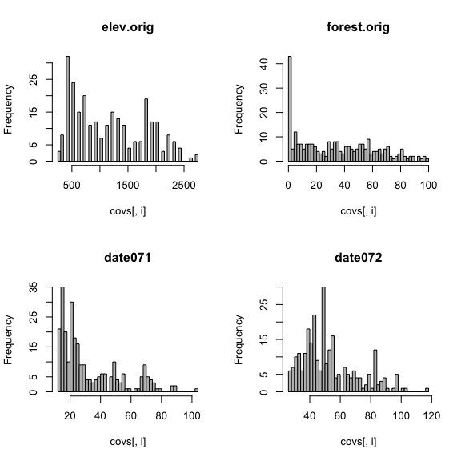

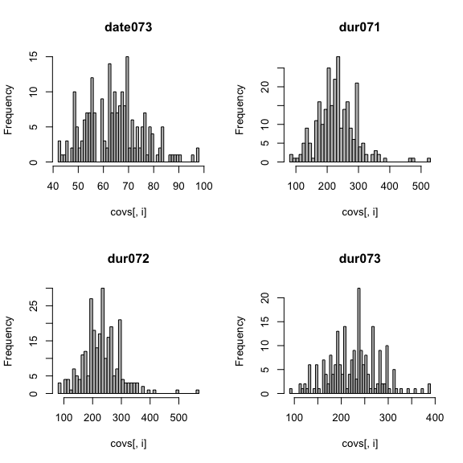

```r
par(mfrow=c(2,2))
for(i in 1:8){
  hist(covs[,i], breaks=50, col="grey", main=colnames(covs)[i])
}
```

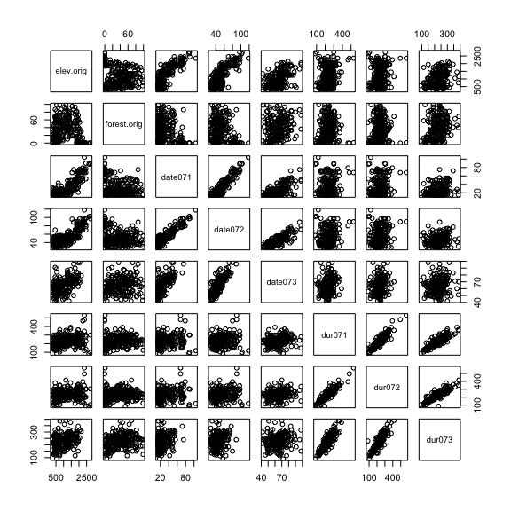

```r
pairs(cbind(elev.orig, forest.orig, date.orig, dur.orig))
```

# ——————————————-

## PASO 2: estandarización de covariables

```r
(means <- c(apply(cbind(elev.orig, forest.orig), 2, mean),
            date.orig=mean(c(date.orig), na.rm=TRUE),
            dur.orig=mean(c(dur.orig), na.rm=TRUE)))
```

```
##   elev.orig forest.orig   date.orig    dur.orig
##  1189.24528    34.49811    49.41232   231.87231
```

```r
(sds <- c(apply(cbind(elev.orig, forest.orig), 2, sd),
          date.orig=sd(c(date.orig), na.rm=TRUE),
          dur.orig=sd(c(dur.orig), na.rm=TRUE)))
```

```
##   elev.orig forest.orig   date.orig    dur.orig
##   639.81487    27.62343    21.58085    60.43774
```

```r
elev <- (elev.orig-means[1])/sds[1]; head(elev); tail(elev)
```

```
## [1] -1.1554050 -1.1554050 -0.2176337 -0.3739289 -0.0613385 -0.9991098
```

```
## [1] 1.032728 1.032728 1.032728 1.970499 1.032728 1.032728
```

```r
forest <- (forest.orig-means[2])/sds[2]; head(forest); tail(forest)
```

```
## [1] -1.14026793 -0.48864723 -0.09043457 -0.92306103  0.01816888 -1.17646908
```

```
## [1]  1.7196229  1.6834218  1.7196229 -1.2488714  1.2490080  0.6697896
```

```r
date <- (date.orig-means[3])/sds[3]; head(date); tail(date)
```

```
##        date071     date072     date073
## [1,] -1.362889 -0.15811774  0.21258121
## [2,] -1.409227  0.02723173  0.30525595
## [3,] -1.270215  0.25891858  0.53694280
## [4,] -1.270215 -0.01910564  0.95397912
## [5,] -1.594576 -0.29712985  0.49060543
## [6,] -1.316552 -0.43614196 -0.01910564
```

```
##            date071   date072  date073
## [260,] -0.94585303 0.3052560 1.046654
## [261,] -0.89951566 0.3979307 1.092991
## [262,]  0.07356910 1.0003165 1.602702
## [263,]  0.86130439 1.3246781       NA
## [264,]  0.02723173 0.4906054 1.278341
## [265,]  0.11990647 0.6296175 1.139329
```

```r
date[is.na(date)] <- 0; head(date); tail(date)
```

```
##        date071     date072     date073
## [1,] -1.362889 -0.15811774  0.21258121
## [2,] -1.409227  0.02723173  0.30525595
## [3,] -1.270215  0.25891858  0.53694280
## [4,] -1.270215 -0.01910564  0.95397912
## [5,] -1.594576 -0.29712985  0.49060543
## [6,] -1.316552 -0.43614196 -0.01910564
```

```
##            date071   date072  date073
## [260,] -0.94585303 0.3052560 1.046654
## [261,] -0.89951566 0.3979307 1.092991
## [262,]  0.07356910 1.0003165 1.602702
## [263,]  0.86130439 1.3246781 0.000000
## [264,]  0.02723173 0.4906054 1.278341
## [265,]  0.11990647 0.6296175 1.139329
```

```r
dur <- (dur.orig-means[4])/sds[4]; head(dur); tail(dur)
```

```
##           dur071     dur072     dur073
## [1,] -0.03097919  1.1272376  0.7963185
## [2,] -0.85827689 -0.8582769 -0.8582769
## [3,] -0.94100666 -0.6100876 -0.9410067
## [4,]  1.12723760  0.3826697  0.1344804
## [5,] -0.85827689 -0.2791685 -0.3618983
## [6,] -0.52735781 -0.5273578 -0.6100876
```

```
##           dur071    dur072    dur073
## [260,] 1.2099674 0.8790483 0.8790483
## [261,] 1.2926971 0.7135888 0.8790483
## [262,] 1.1272376 1.1272376 1.3754269
## [263,] 0.8294104 1.1934214        NA
## [264,] 1.2926971 1.2099674 1.0610538
## [265,] 1.6236162 1.1272376 1.1272376
```

```r
dur[is.na(dur)] <- 0; head(dur); tail(dur)
```

```
##           dur071     dur072     dur073
## [1,] -0.03097919  1.1272376  0.7963185
## [2,] -0.85827689 -0.8582769 -0.8582769
## [3,] -0.94100666 -0.6100876 -0.9410067
## [4,]  1.12723760  0.3826697  0.1344804
## [5,] -0.85827689 -0.2791685 -0.3618983
## [6,] -0.52735781 -0.5273578 -0.6100876
```

```
##           dur071    dur072    dur073
## [260,] 1.2099674 0.8790483 0.8790483
## [261,] 1.2926971 0.7135888 0.8790483
## [262,] 1.1272376 1.1272376 1.3754269
## [263,] 0.8294104 1.1934214 0.0000000
## [264,] 1.2926971 1.2099674 1.0610538
## [265,] 1.6236162 1.1272376 1.1272376
```